# Voxmancer

D&D Audio Drama Generation with Multi-Backend TTS

Lorena Mesa

2026-08-17

## The Question

> *“What happened in town while Axfori was laid up with wound-fever for a tenday?”*

A D&D player wanted to know what the NPCs were doing while their character was away.

**The Solution:** Generate an audio drama in the NPCs’ own voices.

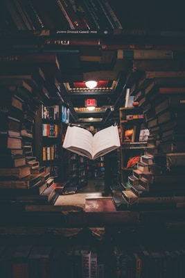

## What is Voxmancer?

Voxmancer converts D&D campaigns into **voiced audio dramas** with:

- 🎭 **Distinct NPC voices** — each character has a consistent voice
- 🤖 **Voice design via prompt engineering** — create voices from text descriptions
- 🔄 **Intelligent voice reuse** — cache voices, reuse when similar
- 🎙️ **Multi-backend TTS** — ElevenLabs (quality), Kokoro (serverless), more
- ☁️ **Serverless deployment** — RunPod Flash with GPU optimization
- 📝 **Campaign to MP3** — end-to-end pipeline in one command

**Use case:** D&D streamers, tabletop RPG content creators, immersive storytelling.

## The Pipeline

```
Campaign YAML
    ↓
[Scene Generation]
  Ollama Mistral (local) or Claude API
    ↓
[Voice Design & Caching]
  Map prompt → voice_id
  Cache in ~/.voxmancer/voices.json
    ↓
[TTS Synthesis]
  ElevenLabs / Kokoro
    ↓
[Audio Rendering]
  FFmpeg concatenate + silence
    ↓
Audio Drama MP3
```

## Multi-Backend Architecture

**ElevenLabs** - Setup: API key - Cost: Per-call ($) - Quality: ⭐⭐⭐⭐⭐ - Use: Voice design, instant

**Kokoro (open-source)** - Setup: Separate Pod or local - Cost: Standing GPU ($$) - Quality: ⭐⭐⭐⭐ - Use: Scale, cost-efficient

**Current demo:** ElevenLabs (minimal ops, voice design API) **Alternative:** Kokoro Pod (better economics at scale)

## Voice Design: Prompt → Voice

```python
from voxmancer.tts.eleven_client import ElevenClient

client = ElevenClient()

# Design a voice from a prompt
voice_id = client.design_voice(
    prompt="An old dwarven blacksmith. Gravelly, warm, gruff."
)

# Use it for speech
audio = client.text_to_speech(
    text="Aye, what brings ye to me forge?",
    voice_id=voice_id
)
```

**Key insight:** ElevenLabs Voice Design API converts text descriptions into unique voice IDs.

## Voice Caching & Reuse

Voxmancer stores voice designs in `~/.voxmancer/voices.json`:

```json
{
  "Brakk Emberhand": {
    "voice_id": "Brakk-ElevenLabs-UUID",
    "prompt": "An old dwarven blacksmith. Gravelly, warm, gruff.",
    "backend": "elevenlabs"
  }
}
```

**Smart reuse:** Before creating a new voice, check similarity: - Prompt ≥ 80% similar? → Reuse existing voice_id - Save API calls, maintain consistency across sessions

## Interactive Demo: Local Workflow

```bash
# 1. Install
poetry install

# 2. Set up environment
export TTS_BACKEND=elevenlabs
export ELEVENLABS_API_KEY=sk_...
export LLM_BACKEND=ollama

# 3. Start Ollama (in another terminal)
ollama serve

# 4. Run demo
poetry run voxmancer workflow --demo

# 5. Listen
open out/elevenlabs_at_the_market.mp3
```

**Output:** 20-minute audio drama with 3+ distinct NPC voices, fully cached.

## RunPod Serverless Deployment

**Pod A: LLM (Ollama Mistral 7B)**

- Generates scenes from campaigns
- Provides HTTP endpoint for Pod B

**Pod B: TTS Handler (Voxmancer)**

- Serverless handler with ElevenLabs API (lightweight image, instant cold-start)
- Handles voice design + audio rendering via API
- Returns MP3 via RunPod async API

## RunPod Pod B Configuration

```
Endpoint: voxmancer-tts
Docker: lorenanicole/voxmancer-serverless:devrel-ready
GPU: Optional (CPU-only for API calls)
Handler: voxmancer.serverless.runpod_handler.handler
Env:
  TTS_BACKEND=elevenlabs
  ELEVENLABS_API_KEY=sk_...
  LLM_BACKEND=runpod_flash
  RUNPOD_LLM_URL=https://...proxy.runpod.net/
  S3_BUCKET=your-bucket-name
  AWS_DEFAULT_REGION=us-east-2
```

**Cost:** ~$0.20/hr (CPU-only) + per-API-call to ElevenLabs

**S3 Auto-Upload:** Generated MP3s upload to S3 with public HTTPS URLs (RunPod injects AWS credentials)

## S3 Storage Integration

Audio files auto-upload to S3:

1. Handler generates MP3
2. boto3 uploads to S3 bucket
3. Returns public HTTPS URL: `https://bucket.s3.region.amazonaws.com/mp3/xxxxx.mp3`
4. Bucket policy allows public read access

**Benefits:** - ✅ Persistent storage (ephemeral serverless pod deleted after job) - ✅ Public download links for streaming/sharing - ✅ Cost-effective (S3 storage cheaper than pod storage) - ✅ No additional setup—RunPod auto-injects AWS credentials

## Troubleshooting & Lessons Learned

**Docker Image Building:** - Pin to commit SHA in Dockerfile: `git checkout ${VOXMANCER_SHA}` - Avoid cached git clones—use `--build-arg` to force fresh code pull - GHCR can have intermittent connectivity issues; Docker Hub more reliable

**TTS Backend Choices:** - Kokoro better deployed on **separate Pod** (dedicated GPU) - ElevenLabs API preferred for serverless (lightweight, instant) - Keep images small (~1.2GB) for fast cold-start

**Debugging:** - Enable logging to stderr for RunPod console visibility - Use Python logging module with stderr stream - Add explicit `sys.stderr.flush()` after critical logs - Environment variables visible in RunPod console logs

**Poetry & Dependencies:** - Always run `poetry lock` after updating `pyproject.toml` - Use `poetry install --only main` in Docker (skip dev deps) - Poetry.lock mismatch causes Docker builds to fail

## Alternative: Kokoro Pod Architecture

For **open-source TTS at scale**, deploy Kokoro on a separate Pod:

**Pod B2: Kokoro TTS Pod** (separate, always-on) - Runs open-source Kokoro model (82M parameters) - GPU: 24GB VRAM (~$3–7/hr) - Serves TTS requests via HTTP proxy

**Pod B1: Voxmancer Handler** (serverless) - Calls Kokoro Pod via HTTP instead of API - Set `TTS_BACKEND=kokoro_http` + `RUNPOD_KOKORO_URL=https://...proxy.runpod.net/` - No vendor lock-in, cheaper per-call at scale

**Trade-off:** Requires standing GPU pod, but eliminates per-API-call costs.

## Modular Architecture

```
voxmancer/
├── core/              # Pipeline stages
│   ├── scene_writer.py       # LLM scene generation
│   ├── voice_designer.py     # Voice creation + caching
│   ├── voice_enricher.py     # Sparse prompt expansion
│   ├── voice_mapper.py       # Voice ID mapping
│   └── renderer.py           # FFmpeg audio synthesis
├── tts/               # TTS backends
│   ├── eleven_client.py      # ElevenLabs API
│   └── kokoro_tts_backend.py # Kokoro TTS
├── llm/               # LLM backends
│   ├── ollama_llm_backend.py
│   └── runpod_llm_backend.py
└── serverless/        # RunPod handlers
    └── runpod_handler.py     # Full pipeline handler
```

**Why modular?** Swap backends, skip stages, test independently.

## Testing Strategy

**57 unit tests covering:**

- Voice caching logic
- Prompt similarity checking
- Scene generation mocking
- TTS client initialization
- Audio rendering (FFmpeg)
- YAML parsing

**CI/CD:** GitHub Actions runs tests on every PR.

## The Tech Stack

- **LLM:** Ollama Mistral (local or RunPod Pod A)
- **TTS:** ElevenLabs (serverless) / Kokoro (local or separate Pod)
- **Audio:** FFmpeg (no GPU required for concatenation)
- **Storage:** S3 (with RunPod auto-injected AWS credentials)
- **Framework:** Python 3.11+, Poetry, Pydantic, boto3
- **Deployment:** RunPod serverless (Pod B) + Pod A for LLM, S3 for persistence
- **CI/CD:** GitHub Actions with pytest coverage, tests on PR

## Next Steps

1. **Try locally:** `poetry run voxmancer workflow --demo`
2. **Deploy:** Follow `RUNPOD_DEPLOYMENT.md`
3. **Customize:** Edit `examples/axfori_campaign.yaml` with your own NPCs
4. **Stream:** Embed MP3 in your D&D content

## Key Takeaways

- 🎙️ Voice design via prompt engineering is powerful
- 🔄 Caching + similarity checking beats API hammering
- ⚡ Serverless TTS + local LLM = cost-effective scale
- 🏗️ Modular architecture = flexible backends
- 📦 Open-source alternatives (Kokoro) reduce vendor lock-in

## Questions?

**GitHub:** github.com/lorenanicole/voxmancer

**Docs:**

- README.md — Quick start
- RUNPOD_DEPLOYMENT.md — Serverless guide
- docs/QUICK_START.md — Local setup

**Try it:**

```bash
poetry run voxmancer workflow --demo
```

## Development & Review

This presentation and project were developed and audited with assistance from **Claude Haiku 4.5**.

**Verification & optimization by Claude:**

- Presentation structure, formatting, and accessibility
- Test harness strategy review (57 unit tests, CI/CD)
- File organization and architecture verification
- Verified Deployment configuration and Docker setup

**August 17, 2026**

## Appendix: Campaign YAML Format

```yaml
title: "Axfori's Market Day"
lead_character: "Axfori"
absence_reason: "recovering at the temple"
npcs:
  - id: brakk-emberhand
    name: "Brakk Emberhand"
    species: dwarf
    role: blacksmith, mentor
    personality: gruff, loyal, warm
    voice_prompt: "Old dwarven blacksmith. Gravelly, warm voice."
```

Campaign files are simple YAML—easy to version control and generate programmatically.